# Python basics 1: Set up a Python programming environment

On this platform, “Python for Science and Art,” I focus on Python programming for scientific research, art, and design. Here, I aim to be interactive and encourage us to share our knowledge with each other. I hope you can learn Python programming in a way that feels useful, easy, and fun.

## Why Python?

If you are a student, engineer, scientist, or even an artist, and you want to learn a new programming language, no doubt, you should pick up Python. There are many reasons:

```
- Simple, easy to learn, and readable
- Available on Windows, macOS, and Unix operating systems
- Large standard library and active community
- Versatile; can be used for a wide range of applications, including web development, data analysis, artificial intelligence, scientific computing, automation, and more
- Free to use
```

Statistics from GitHub and Google show that Python became the most popular programming language in 2020, and its popularity continues to increase.

[figure not shown]

## Install Anaconda and Pycharm

Before starting Python programming, we need to set up a good working environment by installing Anaconda and PyCharm.

Anaconda® Distribution is a Python/R data science distribution that is free, easy to install, and offers free community support. You can follow the installation instructions on the official website: https://docs.anaconda.com/anaconda/install/index.html.

PyCharm is a cross-platform IDE that provides a consistent experience on Windows, macOS, and Linux operating systems. PyCharm is available in three editions: Professional, Community, and Edu. If you are concerned about cost, the free Community edition is sufficient for our topics ((https://www.jetbrains.com/products/compare/?product=pycharm&product=pycharm-ce)).

After installing Anaconda and PyCharm, we need to adjust some settings to make our work more comfortable (See my video):

```
- Add a Python interpreter.
- Play with the Python console.
- Turn on interactive Python, which is more powerful and user-friendly than the standard Python shell.
- Show console variables.
- Create a .py file.
- Run the .py file with the Python console.
```

## Plot a curve

Now we write some codes to plot a sine curve

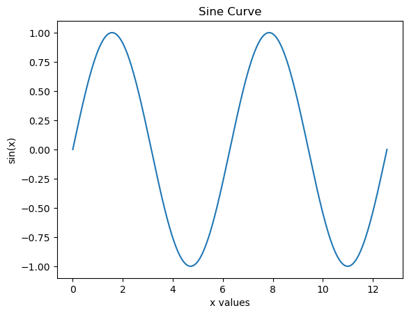

```python
import numpy as np
import matplotlib.pyplot as plt

# Generate x values from 0 to 4π
x = np.linspace(0, 4 * np.pi, 1000)

# Compute the sine of x
y = np.sin(x)

# Create the plot
plt.plot(x, y)

# Add title and labels
plt.title('Sine Curve')
plt.xlabel('x values')
plt.ylabel('sin(x)')

# Display the plot
plt.show()
```

## Read and show an image

Now we read an show an image which is useful for our later programming.

[figure not shown]

```python
import matplotlib.pyplot as plt


# Read the image
img = plt.imread('../images/logo_pySi_500x500.png')

# Display the image
plt.figure()
plt.title('Logo of Python for Science and Art')
plt.imshow(img)
# plt.axis('off')  # Hide axes
plt.show()
```

## Conclusion

You have learned many things in this lesson, including

- Install Anaconda and Pycharm
- The setting of the Pycharm to make your programming easy and fun.
- Plot a curve.
- Read and show an image.

I hope you like my lesson and subscribe my YouTube Channel.